# Trojan Horse Final Project

December 13, 2023

## Installing the libraries

```r
library(tidyverse)
library(tidymodels)
library(tidytext)
library(textrecipes)
library(kableExtra)
library(patchwork) # Side by Side Visuals: Add visuals together
```

## Data Loading & Splitting

```r
trojan_data <- read.csv("/Users/tarikkrestalica/FinalProject/FinalProject/Trojan_Detection.csv")

set.seed(434)
data_split <- initial_split(trojan_data, strata = Class)
train <- training(data_split)
test <- testing(data_split)
```

## Statement of Purpose

With the data set we’ve loaded, our goal is for a given network packet with its records, we want to predict whether or not a network packet is either trojan or benign and find the best predictors and model based on accuracy towards our `Class` variable. This is targeted for businesses, organizations, individuals, large supply chains, and industrial sectors seeking to better protect themselves of these threats, raise awareness of trojan horse, and maintain a safe digital life of trojan horses, and potentially different branches of cyberattacks.

## Executive Summary

The data set that we are working with involves a series of network packets, each populated with crucial information about the packet itself, the method of communication, and a `Class` variable which classifies the network packet as either benign or trojan. Our original goal with this report is to find the best model that predicts whether an incoming network packet is either a benign packet or a trojan packet, and find the most revelant features that contribute to our `Class`, the variable that we want to predict. Due to problems with hyperparameter tuning, and long wait times for code, we only are able to make some predictions with our EDA and the off-the-shelf models. Our `Class` variable is evenly-balanced, with 51% of the network packets being trojan, and 49% of the packets benign. In the EDA, we explore some of the features that are inside the dataset, from `Protocol`, `Total.Fwd.Packets`, `Total.Bwd.Packets`, and `Total.Length.of.Fwd.Packets` to understand the relationship of these variables when a network packet is trojan or benign. We find that for a benign network packet, it requires more forward and backward packets, the size of the forward and backward packet is larger, and larger header lengths, all of these are conducted and evaluated with the use of histograms, boxplots, and summary statistics tables. In the modeling section, we seek to conduct 3 models: a logistic regression model, random forest, and a gradient boosting model, all of which will be off the shelf. Due to the limitations, we will only be able to find the best model and type of model class used to accurately predict our `Class` variable.

## Introduction

In today’s modern-day, digitalized world, there’s nothing more vulnerable to businesses, organizations, industrial sectors, and individuals than the threat of a cyberattack. One of the most common cyberattacks are trojan horses, which is software that appears to be legitimate but harmful under the surface. You can think of a trojan horse as a dubious sabotage: say you got an invitation to a birthday party at Sky Zone from a friend of yours, and it’s a legit invitation, however, just as you enter, you find out that there’s no birthday party after all. You are left puzzled, confused, slightly angry even though you though it was a legitimate event, questioning your friend and wondering where you went wrong. Similarly, whether or not its an application, ad or website, it’s hard for the user to understand if it’s legitimate and real. Network packets are classified as trojan in a variety of ways, from a malicious hacker either initiating the request or during the packet modification process. Mitigating and preventing trojan horse is crucial to help our autonomous way of life stay afloat, something that can only be answered and better understood by understanding the features of our network packet.

## Exploratory Data Analysis

Our data set consists of 177482 rows and 86 columns.

**Column Analysis**

We have 81 numeric columns and 5 categorical columns.

*Missing Values*

```
##                           X                     Flow.ID
##                           0                           0
##                   Source.IP                 Source.Port
##                           0                           0
##              Destination.IP            Destination.Port
##                           0                           0
##                    Protocol                   Timestamp
##                           0                           0
##               Flow.Duration           Total.Fwd.Packets
##                           0                           0
##      Total.Backward.Packets Total.Length.of.Fwd.Packets
##                           0                           0
## Total.Length.of.Bwd.Packets       Fwd.Packet.Length.Max
##                           0                           0
##       Fwd.Packet.Length.Min      Fwd.Packet.Length.Mean
##                           0                           0
##       Fwd.Packet.Length.Std       Bwd.Packet.Length.Max
##                           0                           0
##       Bwd.Packet.Length.Min      Bwd.Packet.Length.Mean
##                           0                           0
##       Bwd.Packet.Length.Std                Flow.Bytes.s
##                           0                           0
##              Flow.Packets.s               Flow.IAT.Mean
##                           0                           0
##                Flow.IAT.Std                Flow.IAT.Max
##                           0                           0
##                Flow.IAT.Min               Fwd.IAT.Total
##                           0                           0
##                Fwd.IAT.Mean                 Fwd.IAT.Std
##                           0                           0
##                 Fwd.IAT.Max                 Fwd.IAT.Min
##                           0                           0
##               Bwd.IAT.Total                Bwd.IAT.Mean
##                           0                           0
##                 Bwd.IAT.Std                 Bwd.IAT.Max
##                           0                           0
##                 Bwd.IAT.Min               Fwd.PSH.Flags
##                           0                           0
##               Bwd.PSH.Flags               Fwd.URG.Flags
##                           0                           0
```

[output cut: 31 more lines]

```
##                           0                           0
##           Subflow.Bwd.Bytes      Init_Win_bytes_forward
##                           0                           0
##     Init_Win_bytes_backward            act_data_pkt_fwd
##                           0                           0
##        min_seg_size_forward                 Active.Mean
##                           0                           0
##                  Active.Std                  Active.Max
##                           0                           0
##                  Active.Min                   Idle.Mean
##                           0                           0
##                    Idle.Std                    Idle.Max
##                           0                           0
##                    Idle.Min                       Class
##                           0                           0
```

From the above data set, we can see that there is not a single missing value for any of our available predictors.

*Firstly, before diving into crucial information about our packets, how is our `Class` column distributed across the data set?*

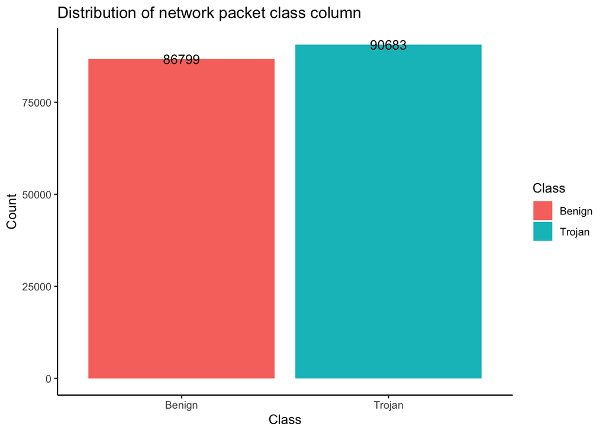

From the plot above, we notice that the distribution of trojan and benign network packets in the data set is well-balanced, and distributed on an almost equal basis. We see than there are more Trojan network packets as opposed to Benign Packets.

Now, we seek to explore the relationship with some of the variables towards our `Class` variable of interest.

*Are there any differences between benign and trojan network packets? To start, first we seek to understand the basic parts from its length, the forward and backward packets, etc. This will be used as a starting point that motivates this discussion.*

**What if we consider the number of forward packets? Do Trojan packets require more forward packets to know the destination?**

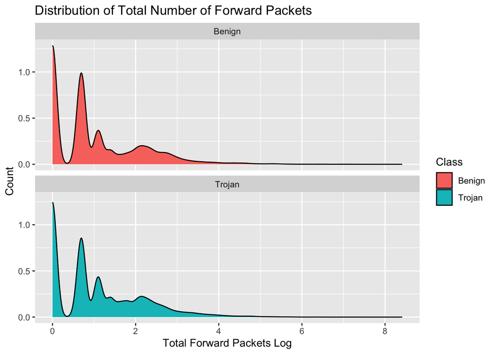

From this, we can see that `Total.Fwd.Packets` is heavily right-skewed when converting it to a logarithm. When looking at the distribution of Benign and Trojan, they are highly similar, which doesn’t tell us much about the relationship between the two variables.

*What happens if we consider a boxplot?*

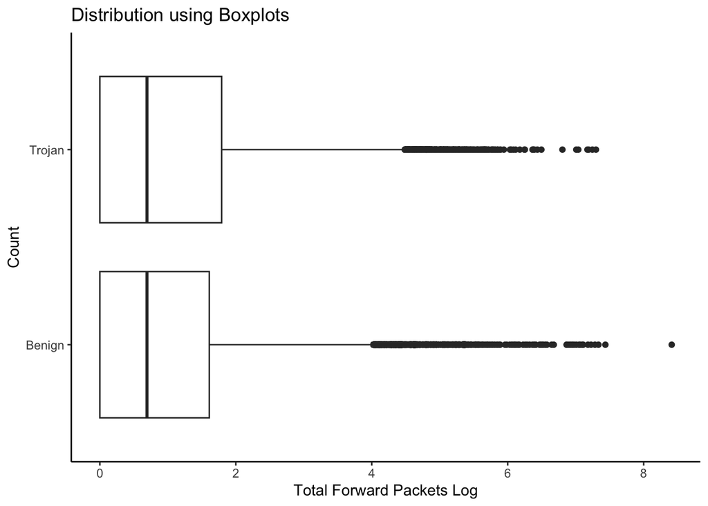

Summary statistics in log packets.

| Class | mean_logTotalFwdPackets | median_logTotalFwdPackets | twentyFifth_logTotalFwdPackets | seventyFifth_logTotalFwdPackets |
| --- | --- | --- | --- | --- |
| Benign | 1.003459 | 0.6931472 | 0 | 1.609438 |
| Trojan | 1.062056 | 0.6931472 | 0 | 1.791759 |

In summary:

- Mean number of log `Total.Fwd.Packets` for Benign network packets: 1.0034588 log packets.
- Mean number of log `Total.Fwd.Packets` for Trojan network packets: 1.0620557 log packets.

Benign network packets require less log forward packets than Trojan network packets based on mean.

*What happens when we convert back to packets from log packets?*

| Class | mean_TotalFwdPackets | median_TotalFwdPackets | twentyFifth_TotalFwdPackets | seventyFifth_TotalFwdPackets |
| --- | --- | --- | --- | --- |
| Benign | 6.951843 | 2 | 1 | 5 |
| Trojan | 6.587132 | 2 | 1 | 6 |

In summary:

- Mean number of `Total.Fwd.Packets` for Benign network packets: 6.9518426 packets.
- Mean number of `Total.Fwd.Packets` for Trojan network packets: 6.5871317 packets.

Benign network packets require more forward packets than Trojan network packets based on mean. This implies that a trojan network packet, it needs less information to go from source to destination.

**Next, what if we consider the number of backward packets? Do Trojan packets require more backward packets to get to the right source?**

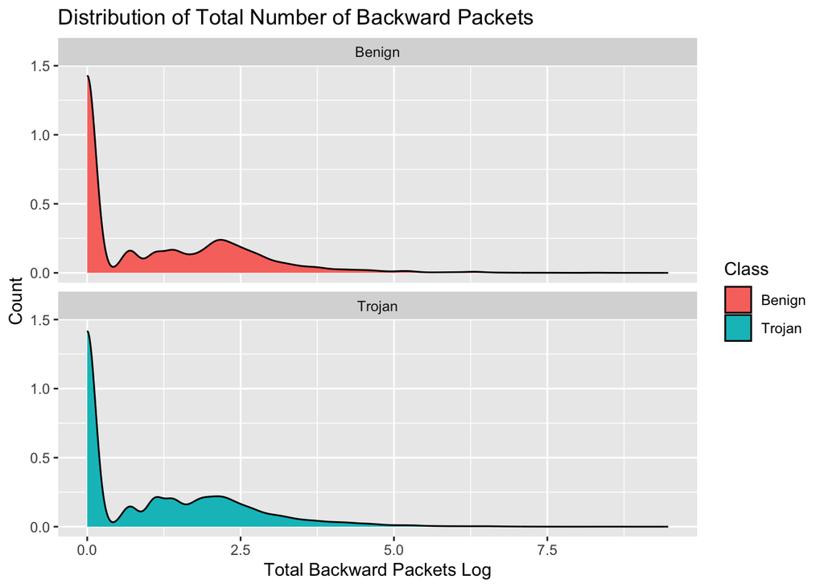

From this, we can see that `Total.Backward.Packets` is heavily right-skewed when converting it to a logarithm. When looking at the distribution of Benign and Trojan, they are highly similar, comparing to the previous density plot between `Total.Fwd.Packets` and our `Class`.

*What happens if we consider a boxplot?*

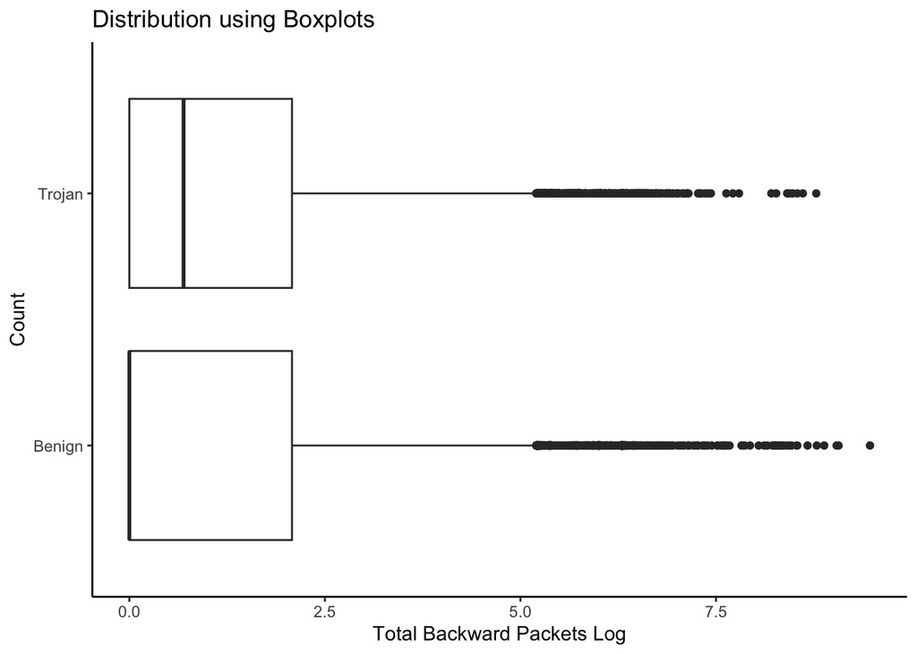

*What happens when we convert back to packets from log packets?*

| Class | mean_TotalBackwardPackets | median_TotalBackwardPackets | twentyFifth_TotalBackwardPackets | seventyFifth_TotalBackwardPackets |
| --- | --- | --- | --- | --- |
| Benign | 11.196439 | 1 | 0 | 4 |
| Trojan | 8.666147 | 1 | 0 | 4 |

In summary:

- Mean number of `Total.Backward.Packets` for Benign network packets: 11.1964393 packets.
- Mean number of `Total.Backward.Packets` for Trojan network packets: 8.6661472 packets.

To summarize, benign network packets on average have more forward and backward packets in order to get from the source to the destination. This could have something to do with the size of the request, and the amount of information you have to work with.

**Now, what happens if we were to consider the length of the packet? What is the relationship between the packet length and Class?**

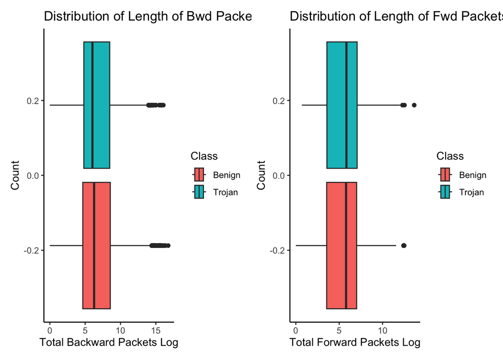

From the visual, based on the median value, we can see that a Trojan forward packet is larger than a Benign packet, but a Benign packet has larger backward packets than a Trojan packet.

*Summary Statistics for Backward Packet Length*

| Class | mean_LengthofBackwardPacket | median_LengthofBackwardPacket | twentyFifth_LengthofBackwardPacket | seventyFifth_LengthofBackwardPacket |
| --- | --- | --- | --- | --- |
| Benign | 12041.492 | 0 | 0 | 469 |
| Trojan | 8468.657 | 50 | 0 | 505 |

*Summary Statistics for Forward Packet Length*

| Class | mean_LengthofForwardPacket | median_LengthofForwardPacket | twentyFifth_LengthofForwardPacket | seventyFifth_LengthofForwardPacket |
| --- | --- | --- | --- | --- |
| Benign | 854.9171 | 31 | 0 | 395 |
| Trojan | 761.6402 | 33 | 0 | 568 |

From the resulting tables, based on the average, we can see that Benign packets require a larger sized forward and backward packet, with an average sized forward packet of 854.9171416 units, and an average size backward packet of 1.2041492^{4}, compared to Trojan packets, which have an average sized forward packet of 761.6401517 and an average sized backward packet of 8468.6572664

Next, because information is spread at ridiculous speeds, it’s important that these packets get to their destination as soon as possible. A great metric to analyze is `Fwd.IAT.Total` & `Bwd.IAT.Total`, which is the total time it took for all the packets to travel to their destination divided by the total packets.

What happens if we convert from log packets to packets?

*Summary Statistics for Forward IAT Total*

| Class | mean_Fwd.IAT.Total | median_Fwd.IAT.Total | twentyFifth_Fwd.IAT.Total | seventyFifth_Fwd.IAT.Total |
| --- | --- | --- | --- | --- |
| Benign | 7028962 | 177847 | 0 | 2538624 |
| Trojan | 9184334 | 230390 | 0 | 5767003 |

For `Fwd.IAT.Total`:

- Benign Packets: 7.0289617^{6} *units of time*
- Trojan Packets: 9.1843342^{6} *units of time*

We can see that the forward IAT(Inter Arrival Time), the time it takes between a packet that has been received until the arrival of the next packet is lower for Benign packets than Trojan packets. In short, packet forwarding is a faster process for Benign network packets than Trojan packets.

*Summary Statistics for Backward IAT Total*

```r
train %>%
  group_by(Class) %>%
  summarize(mean_Bwd.IAT.Total = mean(Bwd.IAT.Total),
            median_Bwd.IAT.Total = median(Bwd.IAT.Total),
            twentyFifth_Bwd.IAT.Total = quantile(Bwd.IAT.Total, 0.25),
            seventyFifth_Bwd.IAT.Total = quantile(Bwd.IAT.Total, 0.75)) %>%
  kable() %>%
  kable_styling(bootstrap_options = c("hover", "striped"))
```

| Class | mean_Bwd.IAT.Total | median_Bwd.IAT.Total | twentyFifth_Bwd.IAT.Total | seventyFifth_Bwd.IAT.Total |
| --- | --- | --- | --- | --- |
| Benign | 5747777 | 0 | 0 | 259928.5 |
| Trojan | 6920582 | 0 | 0 | 276976.0 |

For `Bwd.IAT.Total`:

- Benign Packets: 5.747777^{6} *units of time*
- Trojan Packets: 6.9205818^{6} *units of time*

We can see that the backward IAT(Inter Arrival Time), the time it takes between a packet that has been received by the client to the next packet that arrives is lower for a Benign packet as opposed to a Trojan packet.

To recap and summarize the association between `Bwd.IAT.Total` and `Fwd.IAT.Total` with our `Class`, the `Fwd.IAT.Total` and `Bwd.IAT.Total` is lower for a Benign packet as opposed to a Trojan Packet, potentially as a result to the packet traversal process for a Trojan network packet, and the intents of the hacker who’s responsible for the malicious software.

Next, we take a look at the `Protocol`, and its association with our `Class` variable. A protocol defines how the network packet, which houses the data of the request, governs and exchanges the data to go from its source to its destination. `Protocol` is encoded in terms of a number, signifying the communication lines.

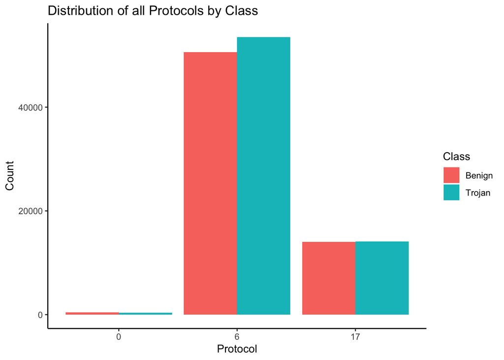

```r
train <- train %>%
  mutate(Protocol = as.factor(Protocol))

train %>%
  ggplot() +
  geom_bar(aes(Protocol, fill = Class), position = "dodge") +
  labs(title = "Distribution of all Protocols by Class",
       x = "Protocol",
       y = "Count") +
  theme_classic()
```

```r
protocol_table <- train %>%
  group_by(Class) %>%
  count(Protocol) %>%
  arrange(Protocol) %>%
  mutate(count = n) %>%
  select(-n)

protocol_table %>%
  kable() %>%
  kable_styling(bootstrap_options = c("hover", "striped"))
```

| Class | Protocol | count |
| --- | --- | --- |
| Benign | 0 | 439 |
| Trojan | 0 | 388 |
| Benign | 6 | 50633 |
| Trojan | 6 | 53519 |
| Benign | 17 | 14027 |
| Trojan | 17 | 14105 |

From the visual, there are only 3 unique protocols that were used for packet communication for the entire data sending and receiving process. We can see that across each of these protocols, Benign and Trojan packets are on a slightly even playing field, slightly equally represented across both the categories. However, from the visual and table, we can infer the following.

In summary:

- Using Protocol 0 as the communication and data transmission method, there were more Benign packets as opposed to Trojan packets in this area.
  - Benign: 439 packets
  - Trojan: 388 packets
- Using Protocol 6 as the communication and data transmission method, there were more Trojan packets as opposed to Benign packets in this area.
  - Benign: 50633packets
  - Trojan: 53519 packets
- Using Protocol 17 as the communication and data transmission method, there are more Trojan packets as opposed to Benign packets in this area.
  - Benign: 14027 packets
  - Trojan: 14105 packets

Now, we seek to understand the relationship between `Fwd.Header.Length` and `Bwd.Header.Length` with our `Class`. If the packet is too long, could that imply a higher likelihood of the packet being a trojan packet?

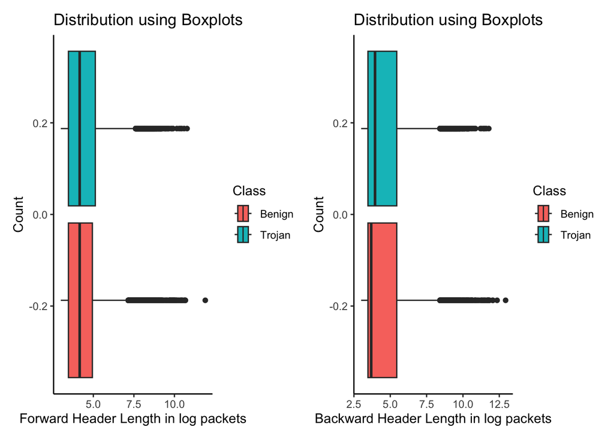

*Summary statistics for Forward Header Length*

| Class | mean_Fwd.Header.Length | median_Fwd.Header.Length | twentyFifth_Fwd.Header.Length | seventyFifth_Fwd.Header.Length |
| --- | --- | --- | --- | --- |
| Benign | 202.1460 | 64 | 32 | 136 |
| Trojan | 194.1123 | 64 | 32 | 168 |

*Summary statistics for Backward Header Length*

| Class | mean_Bwd.Header.Length | median_Bwd.Header.Length | twentyFifth_Bwd.Header.Length | seventyFifth_Bwd.Header.Length |
| --- | --- | --- | --- | --- |
| Benign | 311.6266 | 32 | 0 | 132 |
| Trojan | 242.8177 | 32 | 0 | 136 |

## Model Construction and Interpretation Section

**Logistic Regression**

```r
log_reg_spec <- logistic_reg() %>%
  set_engine("glm") %>%
  set_mode("classification")

log_reg_rec <- recipe(Class ~ ., data = train) %>%
  step_rm(Flow.ID, Source.IP, Destination.IP, Timestamp, X) %>%
  step_zv(all_predictors()) %>%
  step_nzv(all_predictors()) %>%
  step_impute_median(all_numeric_predictors()) %>%
  step_dummy(all_nominal_predictors())

prepped <- prep(log_reg_rec)
juiced <- juice(prepped)

log_reg_wf <- workflow() %>%
  add_model(log_reg_spec) %>%
  add_recipe(log_reg_rec)

log_cv_results <- log_reg_wf %>%
  fit_resamples(train_folds)

log_cv_results %>%
  collect_metrics() %>%
  kable() %>%
  kable_styling(bootstrap_options = c("hover", "striped"))
```

| .metric | .estimator | mean | n | std_err | .config |
| --- | --- | --- | --- | --- | --- |
| accuracy | binary | 0.5436441 | 10 | 0.0016567 | Preprocessor1_Model1 |
| roc_auc | binary | 0.5723127 | 10 | 0.0016816 | Preprocessor1_Model1 |

From the off-the-shelf model, we can see that our `accuracy` metric is around 54.364405 percent, as it does slightly above average towards correctly classifying network packets as either trojan or benign.

**Random Forest**

```r
rf_spec <- rand_forest() %>%
  set_engine("ranger") %>%
  set_mode("classification")

rf_rec <- recipe(Class ~ ., data = train) %>%
  step_rm(all_nominal_predictors(), -Protocol, X) %>%
  step_zv(all_predictors()) %>%
  step_nzv(all_predictors()) %>%
  step_impute_median(all_numeric_predictors()) %>%
  step_dummy(all_nominal_predictors())

prepped <- prep(rf_rec)
juiced <- juice(prepped)

juiced
```

```
## # A tibble: 133,111 × 63
##    Source.Port Destination.Port Flow.Duration Total.Fwd.Packets
##          <int>            <int>         <int>             <int>
##  1       37749               53       1023244                 1
##  2       49387              443           473                 1
##  3       38191              443      46143837                 9
##  4       39888              443      34659660                26
##  5          80            35291             7                 2
##  6       35120              443       4745734                40
##  7       46251              443      72918838                20
##  8       56764               80       4542518                 3
##  9       47994               80       5410908                 4
## 10       57723               80      21856196                 2
## # ℹ 133,101 more rows
## # ℹ 59 more variables: Total.Backward.Packets <int>,
## #   Total.Length.of.Fwd.Packets <dbl>, Total.Length.of.Bwd.Packets <dbl>,
## #   Fwd.Packet.Length.Max <dbl>, Fwd.Packet.Length.Mean <dbl>,
## #   Fwd.Packet.Length.Std <dbl>, Bwd.Packet.Length.Max <dbl>,
## #   Bwd.Packet.Length.Mean <dbl>, Bwd.Packet.Length.Std <dbl>,
## #   Flow.Bytes.s <dbl>, Flow.Packets.s <dbl>, Flow.IAT.Mean <dbl>, …
```

```r
rf_wf <- workflow() %>%
  add_model(rf_spec) %>%
  add_recipe(rf_rec)

# Collect cv results, get the results of the practice exams
rf_cv_results <- rf_wf %>%
  fit_resamples(train_folds) # 73%

rf_cv_results %>%
  collect_metrics() %>%
  kable() %>%
  kable_styling(bootstrap_options = c("hover", "striped"))
```

| .metric | .estimator | mean | n | std_err | .config |
| --- | --- | --- | --- | --- | --- |
| accuracy | binary | 0.7311116 | 10 | 0.0010624 | Preprocessor1_Model1 |
| roc_auc | binary | 0.8166739 | 10 | 0.0009282 | Preprocessor1_Model1 |

What happens if we just consider the features we explored earlier in the modeling process?

```r
rf_new_spec <- rand_forest() %>%
  set_engine("ranger") %>%
  set_mode("classification")

rf_new_rec <- recipe(Class ~ Total.Fwd.Packets + Total.Backward.Packets + Total.Length.of.Fwd.Packets + Total.Length.of.Bwd.Packets + Fwd.IAT.Total + Bwd.IAT.Total + Protocol + Fwd.Header.Length + Bwd.Header.Length, data = train) %>%
  step_zv(all_predictors()) %>%
  step_nzv(all_predictors()) %>%
  step_impute_median(all_numeric_predictors()) %>%
  step_dummy(all_nominal_predictors())

new_prepped <- prep(rf_new_rec)
new_juiced <- juice(new_prepped)

new_juiced
```

```
## # A tibble: 133,111 × 11
##    Total.Fwd.Packets Total.Backward.Packets Total.Length.of.Fwd.Packets
##                <int>                  <int>                       <dbl>
##  1                 1                      1                          30
##  2                 1                      2                          46
##  3                 9                      9                         448
##  4                26                     28                        6359
##  5                 2                      0                           0
##  6                40                     58                        1578
##  7                20                     20                        4556
##  8                 3                      4                         804
##  9                 4                      4                         402
## 10                 2                      0                           0
## # ℹ 133,101 more rows
## # ℹ 8 more variables: Total.Length.of.Bwd.Packets <dbl>, Fwd.IAT.Total <dbl>,
## #   Bwd.IAT.Total <dbl>, Fwd.Header.Length <int>, Bwd.Header.Length <int>,
## #   Class <fct>, Protocol_X6 <dbl>, Protocol_X17 <dbl>
```

```r
rf_wf <- workflow() %>%
  add_model(rf_new_spec) %>%
  add_recipe(rf_new_rec)

rf_new_cv_results <- rf_wf %>%
  fit_resamples(train_folds)

rf_new_cv_results %>% # 68%
  collect_metrics() %>%
  kable() %>%
  kable_styling(bootstrap_options = c("hover", "striped"))
```

| .metric | .estimator | mean | n | std_err | .config |
| --- | --- | --- | --- | --- | --- |
| accuracy | binary | 0.6711917 | 10 | 0.0014520 | Preprocessor1_Model1 |
| roc_auc | binary | 0.7516084 | 10 | 0.0011254 | Preprocessor1_Model1 |

With the second off-the shelf random forest model, our `accuracy` metric is around 0.6711917, meaning that our model is correctly classifying network packets as either trojan or non-trojan 67.119171 percent of the time.

Comparing this model to the first off the shelf model, it does 5.9919936 percentage points worse.

**Gradient Boosting** : Off the shelf due to lag time

```r
xgb_spec <- boost_tree() %>%
  set_engine("xgboost") %>%
  set_mode("classification")

xgb_rec <- recipe(Class ~ ., data = train) %>%
  step_rm(all_nominal_predictors(), -Protocol, X) %>%
  step_zv(all_predictors()) %>%
  step_nzv(all_predictors()) %>%
  step_impute_median(all_numeric_predictors()) %>%
  step_dummy(all_nominal_predictors())

xgb_prep <- prep(xgb_rec)
xgb_juice <- juice(xgb_prep)

xgb_juice
```

```
## # A tibble: 133,111 × 63
##    Source.Port Destination.Port Flow.Duration Total.Fwd.Packets
##          <int>            <int>         <int>             <int>
##  1       37749               53       1023244                 1
##  2       49387              443           473                 1
##  3       38191              443      46143837                 9
##  4       39888              443      34659660                26
##  5          80            35291             7                 2
##  6       35120              443       4745734                40
##  7       46251              443      72918838                20
##  8       56764               80       4542518                 3
##  9       47994               80       5410908                 4
## 10       57723               80      21856196                 2
## # ℹ 133,101 more rows
## # ℹ 59 more variables: Total.Backward.Packets <int>,
## #   Total.Length.of.Fwd.Packets <dbl>, Total.Length.of.Bwd.Packets <dbl>,
## #   Fwd.Packet.Length.Max <dbl>, Fwd.Packet.Length.Mean <dbl>,
## #   Fwd.Packet.Length.Std <dbl>, Bwd.Packet.Length.Max <dbl>,
## #   Bwd.Packet.Length.Mean <dbl>, Bwd.Packet.Length.Std <dbl>,
## #   Flow.Bytes.s <dbl>, Flow.Packets.s <dbl>, Flow.IAT.Mean <dbl>, …
```

```r
xgb_wf <- workflow() %>%
  add_model(xgb_spec) %>%
  add_recipe(xgb_rec)


xgb_cv_results <- xgb_wf %>%
  fit_resamples(train_folds)

xgb_cv_results %>%
  collect_metrics() %>%
  kable() %>%
  kable_styling(bootstrap_options = c("hover", "striped"))
```

| .metric | .estimator | mean | n | std_err | .config |
| --- | --- | --- | --- | --- | --- |
| accuracy | binary | 0.6641300 | 10 | 0.0017272 | Preprocessor1_Model1 |
| roc_auc | binary | 0.7388288 | 10 | 0.0016525 | Preprocessor1_Model1 |

```r
xgb1_accuracy_mean <- xgb_cv_results %>% collect_metrics() %>% filter(.metric == "accuracy") %>% pull(mean)
```

With an off-the shelf gradient boosting model, our `accuracy` metric is around 0.66413, meaning that our model is correctly classifying network packets as either trojan or non-trojan 66.412995 percent of the time.

**Gradient Boosting** : With the EDA variables we’ve explored.

```r
xgb_spec <- boost_tree() %>%
  set_engine("xgboost") %>%
  set_mode("classification")

xgb_rec <- recipe(Class ~ Total.Fwd.Packets + Total.Backward.Packets + Total.Length.of.Fwd.Packets + Total.Length.of.Bwd.Packets + Fwd.IAT.Total + Bwd.IAT.Total + Protocol + Fwd.Header.Length + Bwd.Header.Length, data = train) %>%
  step_zv(all_predictors()) %>%
  step_nzv(all_predictors()) %>%
  step_impute_median(all_numeric_predictors()) %>%
  step_dummy(all_nominal_predictors())

xgb_prep <- prep(xgb_rec)
xgb_juice <- juice(xgb_prep)

xgb_juice
```

```
## # A tibble: 133,111 × 11
##    Total.Fwd.Packets Total.Backward.Packets Total.Length.of.Fwd.Packets
##                <int>                  <int>                       <dbl>
##  1                 1                      1                          30
##  2                 1                      2                          46
##  3                 9                      9                         448
##  4                26                     28                        6359
##  5                 2                      0                           0
##  6                40                     58                        1578
##  7                20                     20                        4556
##  8                 3                      4                         804
##  9                 4                      4                         402
## 10                 2                      0                           0
## # ℹ 133,101 more rows
## # ℹ 8 more variables: Total.Length.of.Bwd.Packets <dbl>, Fwd.IAT.Total <dbl>,
## #   Bwd.IAT.Total <dbl>, Fwd.Header.Length <int>, Bwd.Header.Length <int>,
## #   Class <fct>, Protocol_X6 <dbl>, Protocol_X17 <dbl>
```

```r
xgb_wf <- workflow() %>%
  add_model(xgb_spec) %>%
  add_recipe(xgb_rec)


xgb_cv_results <- xgb_wf %>%
  fit_resamples(train_folds)

xgb_cv_results %>%
  collect_metrics() %>%
  kable() %>%
  kable_styling(bootstrap_options = c("hover", "striped"))
```

| .metric | .estimator | mean | n | std_err | .config |
| --- | --- | --- | --- | --- | --- |
| accuracy | binary | 0.6218644 | 10 | 0.0012748 | Preprocessor1_Model1 |
| roc_auc | binary | 0.6831437 | 10 | 0.0013210 | Preprocessor1_Model1 |

```r
xgb2_accuracy_mean <- xgb_cv_results %>% collect_metrics() %>% filter(.metric == "accuracy") %>% pull(mean)
```

## Conclusion

For future analysis, future data scientists will want to attempt to reduce down the training set in such a way to allow for faster compute time for optimal hyperparameters for our models. Faster computing times will allow for data scientists to quickly understand and find relationships between the model parameters and maximizing our `accuracy` metric. In addition, because of the limitations I faced with this project, we also want to understand the most relevant features for predicting `Class`, and it’s not enough to just rely on our EDA and off the shelf models.

In addition, future questions data scientists could answer is as follows:

- What model class will allow us to maximize a different metric, like `recall`, `precision`, and `ROC-AUC`?
- Conduct a logistic regression model to find the most relevant and statistically significant features from the data set? Across a set of predictors, at what range of values do we see a change in the predicted `Class` of the network packet? Which variables are positively correlated or negatively correlated with our `Class`?
- Can we extrapolate information from the components of our `Flow.ID` as useful predictors for our `Class` variable?
- Are `Source.IP`, `Destination.IP`, `Source.Port`, `Source.IP`, `Destination.IP` useful predictors? Which types of ports and IP addresses are trojan or benign? How could we use this information to conduct a meaningful analysis with our `Class` variable in our EDA and modeling workflow?

Despite the limitations I’ve encountered, this is a great passion project for those who are interested in learning more about network security, trojan horses, and want to dive deeper into a highly complex topic.

## References

- Missing values for each column: https://www.projectpro.io/recipes/find-count-of-missing-values-dataframe#:~:text=We%20will%20use%20built%2Din,times%20the%20condition%20was%20True.&text=To%20calculate%20the%20number%20of,We%20use%20colSums()%20function.
- Packet Forwarding: https://www.geeksforgeeks.org/what-is-packet-forwarding/
- Bar graph to show counts: https://www.cedricscherer.com/2021/07/05/a-quick-how-to-on-labelling-bar-graphs-in-ggplot2/

*Tuning my recipe parameters: https://stackoverflow.com/questions/70941388/how-to-prep-a-recipe-including-tunable-arguments